# Course6Week4Assignment-YR-Part1

Yonatan Rafael

==============================================================

### Overview

Part 2 of this report is a deep dive of ToothGrowth data.

### Exploratory data analyses and Summary

Load the ToothGrowth data set. Check out the top lines, dimensions to cover basic exploratory analysis.

```r
library(datasets)
data("ToothGrowth")
head(ToothGrowth)
```

```
##    len supp dose
## 1  4.2   VC  0.5
## 2 11.5   VC  0.5
## 3  7.3   VC  0.5
## 4  5.8   VC  0.5
## 5  6.4   VC  0.5
## 6 10.0   VC  0.5
```

```r
dim(ToothGrowth)
```

```
## [1] 60  3
```

```r
str(ToothGrowth)
```

```
## 'data.frame':    60 obs. of  3 variables:
##  $ len : num  4.2 11.5 7.3 5.8 6.4 10 11.2 11.2 5.2 7 ...
##  $ supp: Factor w/ 2 levels "OJ","VC": 2 2 2 2 2 2 2 2 2 2 ...
##  $ dose: num  0.5 0.5 0.5 0.5 0.5 0.5 0.5 0.5 0.5 0.5 ...
```

Provide a summary of the data.

```r
summary(ToothGrowth)
```

```
##       len        supp         dose
##  Min.   : 4.20   OJ:30   Min.   :0.500
##  1st Qu.:13.07   VC:30   1st Qu.:0.500
##  Median :19.25           Median :1.000
##  Mean   :18.81           Mean   :1.167
##  3rd Qu.:25.27           3rd Qu.:2.000
##  Max.   :33.90           Max.   :2.000
```

Visualize data by supplement and dose.

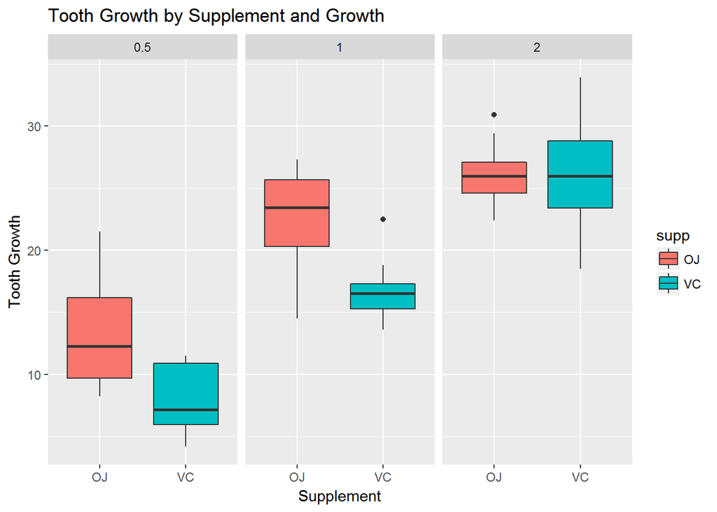

```r
library(ggplot2)
g <- ggplot(ToothGrowth, aes(supp, len, fill = supp)) + geom_boxplot() + facet_grid(.~dose) + labs(x = "Supplement", y = "Tooth Growth", title = "Tooth Growth by Supplement and Growth")
print(g)
```

### Testing

Test #1 will check to see if the OJ supplement is more impactful in growing teeth than the VC supplement. - Null hypothesis: OJ = VC. - Alternative hypothesis: OJ > VC

```r
OJtable <- ToothGrowth[ToothGrowth$supp == "OJ", 1]
VCtable <- ToothGrowth[ToothGrowth$supp == "VC", 1]
t.test(OJtable, VCtable, alternative = "greater", paired = FALSE, var.equal = FALSE, conf.level = .95)
```

```
##
##  Welch Two Sample t-test
##
## data:  OJtable and VCtable
## t = 1.9153, df = 55.309, p-value = 0.03032
## alternative hypothesis: true difference in means is greater than 0
## 95 percent confidence interval:
##  0.4682687       Inf
## sample estimates:
## mean of x mean of y
##  20.66333  16.96333
```

The p-value of .03032 is less than .05, so we are 95% confident that the effect of the OJ supplement is greater than the effect of the VC supplement.

Test #2 will see if there is a difference in effect for OJ versus VC, when the dosage is 2. Null hypothesis: OJ when dosaage is 2 = VC when dosage is 2 Alternative hypothesis: OJ when dosage is 2 /= VC when dosage is 2

```r
OJtable2 <- ToothGrowth[ToothGrowth$supp == "OJ" & ToothGrowth$dose == "2", 1]
VCtable2 <- ToothGrowth[ToothGrowth$supp == "VC" & ToothGrowth$dose == "2", 1]
t.test(OJtable2, VCtable2, alternative = "two.sided", paired = FALSE, var.equal = FALSE, conf.level = .95)
```

```
##
##  Welch Two Sample t-test
##
## data:  OJtable2 and VCtable2
## t = -0.046136, df = 14.04, p-value = 0.9639
## alternative hypothesis: true difference in means is not equal to 0
## 95 percent confidence interval:
##  -3.79807  3.63807
## sample estimates:
## mean of x mean of y
##     26.06     26.14
```

With a p-value = .9639, we fail to reject the possibility that the effect of OJ and VC are the same when dosage is 2.

### Assumption and Conclusions

Assumptions: 1. Populations are independent and random populations were used. 2. The sample population is normally distributed.

Conclusion: The effect of OJ is greater than the effect of VC, excpect for when the dosage is 2.